# Week 4 tidyr

Take time to answer each question and create working code that you understand.

As you go through the activity, try to complete the exercise on your own. Each exercise is meant to take 5-10 minutes. If you are stuck or lost, try watching the code solution video linked at the bottom of the file.

## Background

Each semester BYU-Idaho holds a Research and Creative Works Conference (R&CW) where on-campus students can display key projects they have worked on during the semester. We will be analyzing the R&CW. Our goal is to see how many projects come from which departments over time.

## Read in data

To start, run this code to read in the data:

```r
library(tidyverse, warn.conflicts = FALSE)
dat <- read_csv("https://byuistats.github.io/M335/data/rcw_reshape.csv")
dat
```

```
## # A tibble: 35 × 5
##     Year Semester Semester_Date Count Department
##    <dbl> <chr>    <chr>         <dbl> <chr>
##  1  2016 Spring   4/1/2016          7 Chem
##  2  2016 Fall     9/1/2016         10 Chem
##  3  2017 Winter   1/1/2017         21 Chem
##  4  2017 Spring   4/1/2017          8 Chem
##  5  2017 Fall     9/1/2017         12 Chem
##  6  2018 Winter   1/1/2018         16 Chem
##  7  2016 Spring   4/1/2016         27 CSEE
##  8  2016 Fall     9/1/2016         15 CSEE
##  9  2017 Winter   1/1/2017         13 CSEE
## 10  2017 Spring   4/1/2017         18 CSEE
## # ℹ 25 more rows
```

*Is the data in long or wide format? How can you tell?*

## Pivoting

Instructions: 1. Using what you learned in the reading, convert the data to wide format (one column per Department) and save it under a new name 2. Now convert the wide dataset back to long format

```r
#convert it to wide here
dat_wide <- dat %>% pivot_wider(names_from = Department, values_from = Count)
dat_wide
```

```
## # A tibble: 6 × 10
##    Year Semester Semester_Date  Chem  CSEE   DCM   GEO  Math    ME   PHY
##   <dbl> <chr>    <chr>         <dbl> <dbl> <dbl> <dbl> <dbl> <dbl> <dbl>
## 1  2016 Spring   4/1/2016          7    27    NA     4     2    38     5
## 2  2016 Fall     9/1/2016         10    15     1    NA     2    41    11
## 3  2017 Winter   1/1/2017         21    13     1    14    NA    28     8
## 4  2017 Spring   4/1/2017          8    18     2    NA     5    15    NA
## 5  2017 Fall     9/1/2017         12     7    NA    NA     2    18     7
## 6  2018 Winter   1/1/2018         16    11     1    14     2    29     5
```

```r
#now convert the wide data back to long format

dat_long <- dat_wide %>% pivot_longer(c(`Chem`,`CSEE`,`DCM`,`GEO`,`Math`,`ME`,`PHY`),names_to = "Department", values_to = "count")

dat_long <- dat_wide %>% pivot_longer(cols = Chem:PHY,names_to = "Department", values_to = "count")

dat_long
```

```
## # A tibble: 42 × 5
##     Year Semester Semester_Date Department count
##    <dbl> <chr>    <chr>         <chr>      <dbl>
##  1  2016 Spring   4/1/2016      Chem           7
##  2  2016 Spring   4/1/2016      CSEE          27
##  3  2016 Spring   4/1/2016      DCM           NA
##  4  2016 Spring   4/1/2016      GEO            4
##  5  2016 Spring   4/1/2016      Math           2
##  6  2016 Spring   4/1/2016      ME            38
##  7  2016 Spring   4/1/2016      PHY            5
##  8  2016 Fall     9/1/2016      Chem          10
##  9  2016 Fall     9/1/2016      CSEE          15
## 10  2016 Fall     9/1/2016      DCM            1
## # ℹ 32 more rows
```

```r
dat1 <- dat %>% pivot_wider(names_from = Department, values_from = Count)

dat1 <- dat1 %>% pivot_longer(cols = Chem:PHY,names_to = "Department", values_to = "count")
```

### Discussion/Observation:

- *How many rows does the new long format have?*
- *How does that compare with the original data? Why?*
- *What argument in pivot_longer() could you change so that the “new” long format data matches the data you originally read in.*
- *Discuss: When might you want to make implicit NA’s explicit? Why would you not?*

## Diving deeper into implicit/explicit missing values

Instructions:

3. Explore the following related functions/arguments, make notes as desired
- within pivot_wider( value_fill = )
- within pivot_longer( values_drop_na = )
- complete()
- expand()
4. Using one (or more) of these commands, edit the original dataset so that the implicit missing values are made explicit; and instead of a missing value for “Count” they have zeros. Save this dataset as zeros.

```r
dat2 <- dat1

dat2 <- dat2 %>% complete()

dat2$count <- replace(dat2$count, is.na(dat2$count), 0)

dat2
```

```
## # A tibble: 42 × 5
##     Year Semester Semester_Date Department count
##    <dbl> <chr>    <chr>         <chr>      <dbl>
##  1  2016 Spring   4/1/2016      Chem           7
##  2  2016 Spring   4/1/2016      CSEE          27
##  3  2016 Spring   4/1/2016      DCM            0
##  4  2016 Spring   4/1/2016      GEO            4
##  5  2016 Spring   4/1/2016      Math           2
##  6  2016 Spring   4/1/2016      ME            38
##  7  2016 Spring   4/1/2016      PHY            5
##  8  2016 Fall     9/1/2016      Chem          10
##  9  2016 Fall     9/1/2016      CSEE          15
## 10  2016 Fall     9/1/2016      DCM            1
## # ℹ 32 more rows
```

```r
dat2[is.na(dat2)] <- 0
dat2
```

```
## # A tibble: 42 × 5
##     Year Semester Semester_Date Department count
##    <dbl> <chr>    <chr>         <chr>      <dbl>
##  1  2016 Spring   4/1/2016      Chem           7
##  2  2016 Spring   4/1/2016      CSEE          27
##  3  2016 Spring   4/1/2016      DCM            0
##  4  2016 Spring   4/1/2016      GEO            4
##  5  2016 Spring   4/1/2016      Math           2
##  6  2016 Spring   4/1/2016      ME            38
##  7  2016 Spring   4/1/2016      PHY            5
##  8  2016 Fall     9/1/2016      Chem          10
##  9  2016 Fall     9/1/2016      CSEE          15
## 10  2016 Fall     9/1/2016      DCM            1
## # ℹ 32 more rows
```

```r
#using pivot with values_fill
zeros <- dat %>% pivot_wider(names_from = Department, values_from = Count, values_fill = 0) %>%
  pivot_longer(cols = Chem:PHY, names_to = "Department", values_to = "Count")
zeros
```

```
## # A tibble: 42 × 5
##     Year Semester Semester_Date Department Count
##    <dbl> <chr>    <chr>         <chr>      <dbl>
##  1  2016 Spring   4/1/2016      Chem           7
##  2  2016 Spring   4/1/2016      CSEE          27
##  3  2016 Spring   4/1/2016      DCM            0
##  4  2016 Spring   4/1/2016      GEO            4
##  5  2016 Spring   4/1/2016      Math           2
##  6  2016 Spring   4/1/2016      ME            38
##  7  2016 Spring   4/1/2016      PHY            5
##  8  2016 Fall     9/1/2016      Chem          10
##  9  2016 Fall     9/1/2016      CSEE          15
## 10  2016 Fall     9/1/2016      DCM            1
## # ℹ 32 more rows
```

```r
# Using complete
# Just to show that add new combinations (emties)
dat %>% complete(Year,Semester, Department, fill = list(Count = 0, Semester_Date = "2") )
```

```
## # A tibble: 63 × 5
##     Year Semester Department Semester_Date Count
##    <dbl> <chr>    <chr>      <chr>         <dbl>
##  1  2016 Fall     Chem       9/1/2016         10
##  2  2016 Fall     CSEE       9/1/2016         15
##  3  2016 Fall     DCM        9/1/2016          1
##  4  2016 Fall     GEO        2                 0
##  5  2016 Fall     Math       9/1/2016          2
##  6  2016 Fall     ME         9/1/2016         41
##  7  2016 Fall     PHY        9/1/2016         11
##  8  2016 Spring   Chem       4/1/2016          7
##  9  2016 Spring   CSEE       4/1/2016         27
## 10  2016 Spring   DCM        2                 0
## # ℹ 53 more rows
```

```r
# work well without adding any new combination, and fill
dat %>% complete(Department, nesting(Year, Semester, Semester_Date), fill = list(Count = 0))
```

```
## # A tibble: 42 × 5
##    Department  Year Semester Semester_Date Count
##    <chr>      <dbl> <chr>    <chr>         <dbl>
##  1 Chem        2016 Fall     9/1/2016         10
##  2 Chem        2016 Spring   4/1/2016          7
##  3 Chem        2017 Fall     9/1/2017         12
##  4 Chem        2017 Spring   4/1/2017          8
##  5 Chem        2017 Winter   1/1/2017         21
##  6 Chem        2018 Winter   1/1/2018         16
##  7 CSEE        2016 Fall     9/1/2016         15
##  8 CSEE        2016 Spring   4/1/2016         27
##  9 CSEE        2017 Fall     9/1/2017          7
## 10 CSEE        2017 Spring   4/1/2017         18
## # ℹ 32 more rows
```

```r
# Expand with a left join to add the counts and replace-na
dat %>% expand(Department,nesting(Year, Semester, Semester_Date)) %>%
  left_join(dat) %>% replace_na(list(Count = 0))
```

```
## # A tibble: 42 × 5
##    Department  Year Semester Semester_Date Count
##    <chr>      <dbl> <chr>    <chr>         <dbl>
##  1 Chem        2016 Fall     9/1/2016         10
##  2 Chem        2016 Spring   4/1/2016          7
##  3 Chem        2017 Fall     9/1/2017         12
##  4 Chem        2017 Spring   4/1/2017          8
##  5 Chem        2017 Winter   1/1/2017         21
##  6 Chem        2018 Winter   1/1/2018         16
##  7 CSEE        2016 Fall     9/1/2016         15
##  8 CSEE        2016 Spring   4/1/2016         27
##  9 CSEE        2017 Fall     9/1/2017          7
## 10 CSEE        2017 Spring   4/1/2017         18
## # ℹ 32 more rows
```

## Practice separate() and unite()

Starting with your zeros data:

5. Take Semester_Date column and separate it into a year, month, and day columns.
6. unite() the Year and Semester columns for potentially easier labelling of the graphic. (I actually prefer using paste() instead of unite(), so you could get familiar with that command as well)
7. Now create a line chart that shows the combined Year-Semester variable along the x axis and the count of projects on the y axis for each department.

```r
#5
# usse separate and change the type of the charachter day to numeric
dat2 <- dat2 %>% separate(col = Semester_Date, into = (c("day","month", "year"))) %>%
  mutate(day = as.numeric(day))



#6

# with paste into mutate

zeros %>% mutate(yrsem = paste(Year, Semester, sep = ""))
```

```
## # A tibble: 42 × 6
##     Year Semester Semester_Date Department Count yrsem
##    <dbl> <chr>    <chr>         <chr>      <dbl> <chr>
##  1  2016 Spring   4/1/2016      Chem           7 2016Spring
##  2  2016 Spring   4/1/2016      CSEE          27 2016Spring
##  3  2016 Spring   4/1/2016      DCM            0 2016Spring
##  4  2016 Spring   4/1/2016      GEO            4 2016Spring
##  5  2016 Spring   4/1/2016      Math           2 2016Spring
##  6  2016 Spring   4/1/2016      ME            38 2016Spring
##  7  2016 Spring   4/1/2016      PHY            5 2016Spring
##  8  2016 Fall     9/1/2016      Chem          10 2016Fall
##  9  2016 Fall     9/1/2016      CSEE          15 2016Fall
## 10  2016 Fall     9/1/2016      DCM            1 2016Fall
## # ℹ 32 more rows
```

```r
# with unite
zeros <- zeros %>% unite("yrsem",c(Year, Semester,), sep = "", remove = FALSE)

#dat2 <- dat2 %>% unite(new, month, year)
dat2 <- dat2 %>% unite(year_semester, Year, Semester, sep = "-")

zeros
```

```
## # A tibble: 42 × 6
##    yrsem       Year Semester Semester_Date Department Count
##    <chr>      <dbl> <chr>    <chr>         <chr>      <dbl>
##  1 2016Spring  2016 Spring   4/1/2016      Chem           7
##  2 2016Spring  2016 Spring   4/1/2016      CSEE          27
##  3 2016Spring  2016 Spring   4/1/2016      DCM            0
##  4 2016Spring  2016 Spring   4/1/2016      GEO            4
##  5 2016Spring  2016 Spring   4/1/2016      Math           2
##  6 2016Spring  2016 Spring   4/1/2016      ME            38
##  7 2016Spring  2016 Spring   4/1/2016      PHY            5
##  8 2016Fall    2016 Fall     9/1/2016      Chem          10
##  9 2016Fall    2016 Fall     9/1/2016      CSEE          15
## 10 2016Fall    2016 Fall     9/1/2016      DCM            1
## # ℹ 32 more rows
```

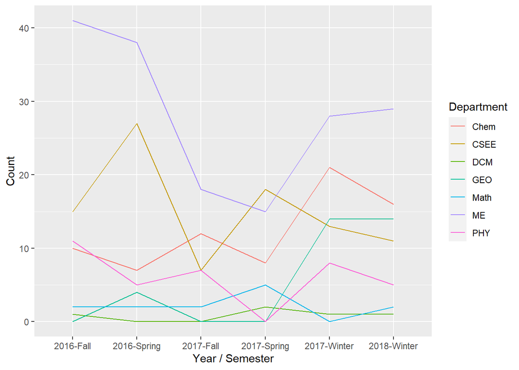

```r
#7

ggplot(dat2) +
  aes(x = year_semester, y =count, group = Department, color = Department) +
  geom_line() +
#  facet_grid( . ~ year) +


   labs(x= "Year / Semester",
       y = "Count")
```

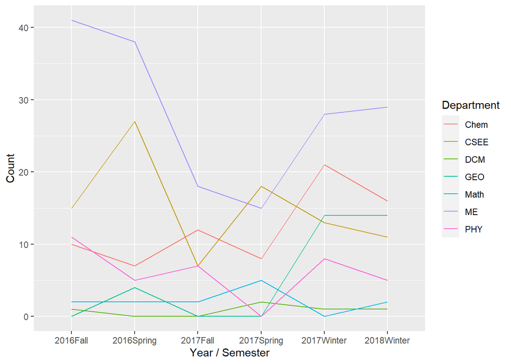

```r
ggplot(zeros) +
  aes(x = yrsem, y = Count, group = Department, color = Department) +
  geom_line() +
#  facet_grid( . ~ year) +


   labs(x= "Year / Semester",
       y = "Count")
```

You may notice that the semesters are out of chronological order. That is because the new combined column of year and semester is probably being treated as a character vector, which will always be in alphabetical order.

We want to make the Year-Semester column a factor so that we can control/specify the order of the levels.

```r
#dat2 <- factor(dat2, "year_semester")
# factor year semester

dat2 <- dat2 %>% mutate(year_semester = factor( level = c("2016Spring","2016Fall","2017Winter","2017Spring","2017Fall","2018Winter")))
```

```
## Error in `mutate()`:
## ℹ In argument: `year_semester = factor(...)`.
## Caused by error:
## ! `year_semester` must be size 42 or 1, not 0.
```

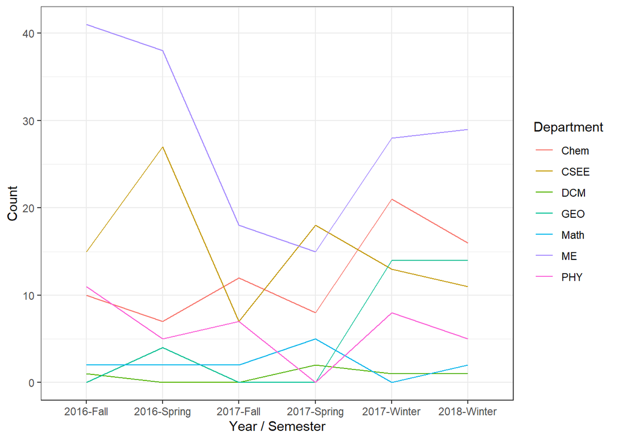

```r
ggplot(dat2) +
  aes(x = year_semester, y = count, group = Department, color = Department) +
  geom_line() +
#  facet_grid( . ~ year) +

  theme_bw() +
   labs(x= "Year / Semester",
       y = "Count")
```

[Part 1 Solution to pivoting and implicit NA](https://www.loom.com/share/d49bb263d8194e60b58465a45d1b49c6?sharedAppSource=personal_library)

[Part 2 Separate, Unite and Factors](https://www.loom.com/share/26b5f4b094cd4c8c8bc82c381c71730a)